# vfrench_FinalHomeworkCode_03

Victoria French

10/14/2021

# Homework 3

## Data

Data includes the first name, last name, and gender of the entire population of 1000 people who have survived the zombie apocalypse and are now ekeing out an existence somewhere on the East Coast, along with several other variables (height, weight, age, number of years of education, number of zombies they have killed, and college major;

```r
library(curl)
f<- curl('https://raw.githubusercontent.com/fuzzyatelin/fuzzyatelin.github.io/master/AN588_Fall21/zombies.csv')
d <- read.csv(f, header=TRUE, stringsAsFactors = FALSE)
```

```r
str(d)
```

```
## 'data.frame':    1000 obs. of  10 variables:
##  $ id                : int  1 2 3 4 5 6 7 8 9 10 ...
##  $ first_name        : chr  "Sarah" "Mark" "Brandon" "Roger" ...
##  $ last_name         : chr  "Little" "Duncan" "Perez" "Coleman" ...
##  $ gender            : chr  "Female" "Male" "Male" "Male" ...
##  $ height            : num  62.9 67.8 72.1 66.8 64.7 ...
##  $ weight            : num  132 146 153 130 132 ...
##  $ zombies_killed    : int  2 5 1 5 4 1 0 4 9 2 ...
##  $ years_of_education: int  1 3 1 6 3 4 4 0 3 3 ...
##  $ major             : chr  "medicine/nursing" "criminal justice administration" "education" "energy studies" ...
##  $ age               : num  17.6 22.6 21.9 18.2 21.1 ...
```

## Population parameters

Calculate the population mean and standard deviation for each quantitative random variable (height, weight, age, number of zombies killed, and years of education). NOTE: You will not want to use the built in var() and sd() commands as these are for samples.

### Mean

Mean = the sum of measured values divided by n = the average or the arithemetic mean

### Variance

Since we cannot use built in R functions we can use the following statements to build our own function in R for population variance.

sum of squares = the sum of the squared deviations of a set of values from the mean

population variance = sum of squares / N

The standard deviation is simply the square root of the variance

```r
popv <- function(x) {
    sum((x - mean(x))^2)/(length(x))
}
```

```r
popsd <- function(x) {
    sqrt(popv(x))
}
```

*good*

### Calculations

```r
hm <- mean(d$height)
hm
```

```
## [1] 67.6301
```

```r
hsd <- popsd(d$height)
hsd
```

```
## [1] 4.30797
```

```r
wm <- mean(d$weight)
wm
```

```
## [1] 143.9075
```

```r
wsd <- popsd(d$weight)
wsd
```

```
## [1] 18.39186
```

```r
am <- mean(d$age)
am
```

```
## [1] 20.04696
```

```r
asd <- popsd(d$age)
asd
```

```
## [1] 2.963583
```

```r
zm <- mean(d$zombies_killed)
zm
```

```
## [1] 2.992
```

```r
zsd <- popsd(d$zombies_killed)
zsd
```

```
## [1] 1.747551
```

```r
em <- mean(d$years_of_education)
em
```

```
## [1] 2.996
```

```r
esd <- popsd(d$years_of_education)
esd
```

```
## [1] 1.675704
```

### Visualizing Data

Use {ggplot} to make boxplots of each of these variables by gender.

```r
library(ggplot2)
```

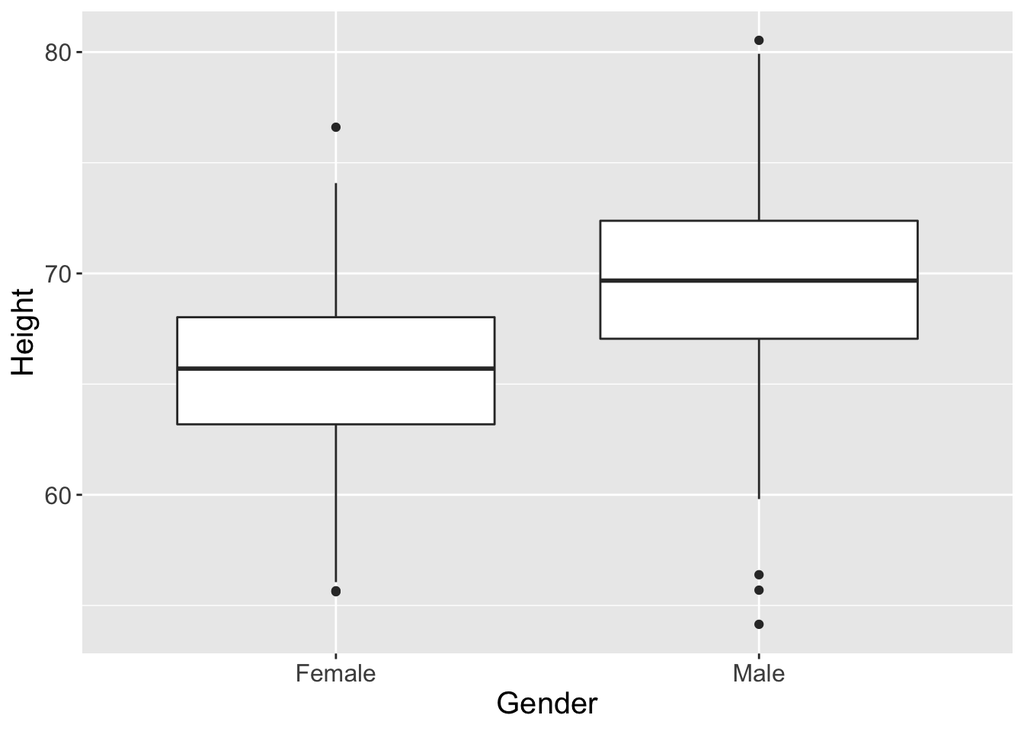

```r
hbp <- ggplot(d, aes(x = gender, y= height)) #ggplot() initializes a ggplot object.
hbp <- hbp + geom_boxplot() #need to add a layer with geom_boxplot to visualize five summary statistics (the median, two hinges and two whiskers), and all "outlying" points individually.
hbp <- hbp + labs(x= 'Gender', y ='Height') +  theme(text=element_text(size=15)) #labs defines labels and theme alows you to adjust any non data elements including font size, color, family etc.
hbp
```

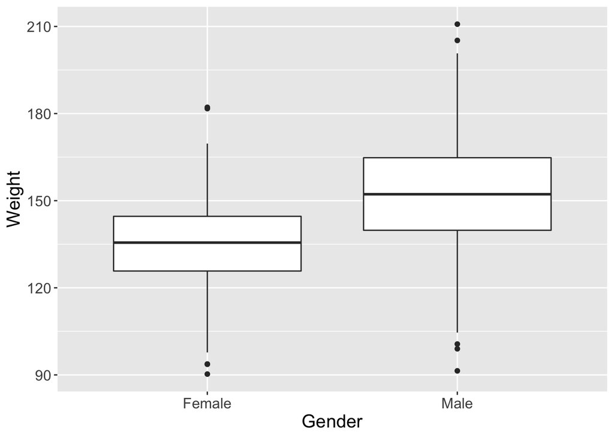

```r
wbp <- ggplot(d, aes(x=gender, y=weight)) + geom_boxplot() + xlab ('Gender') + ylab ('Weight') + theme(text=element_text(size=15)) #can also just write out each element like an equation with one line of code.
wbp
```

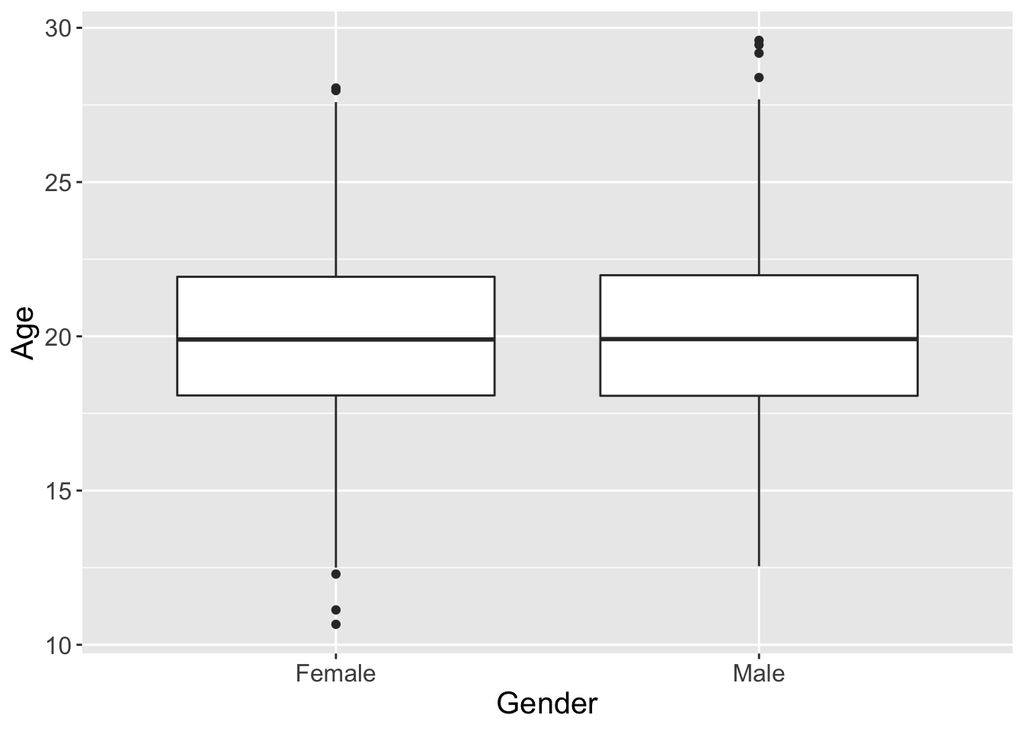

```r
abp <- ggplot(d, aes(x=gender, y=age)) + geom_boxplot() + xlab ('Gender') + ylab ('Age') + theme(text=element_text(size=15))
abp
```

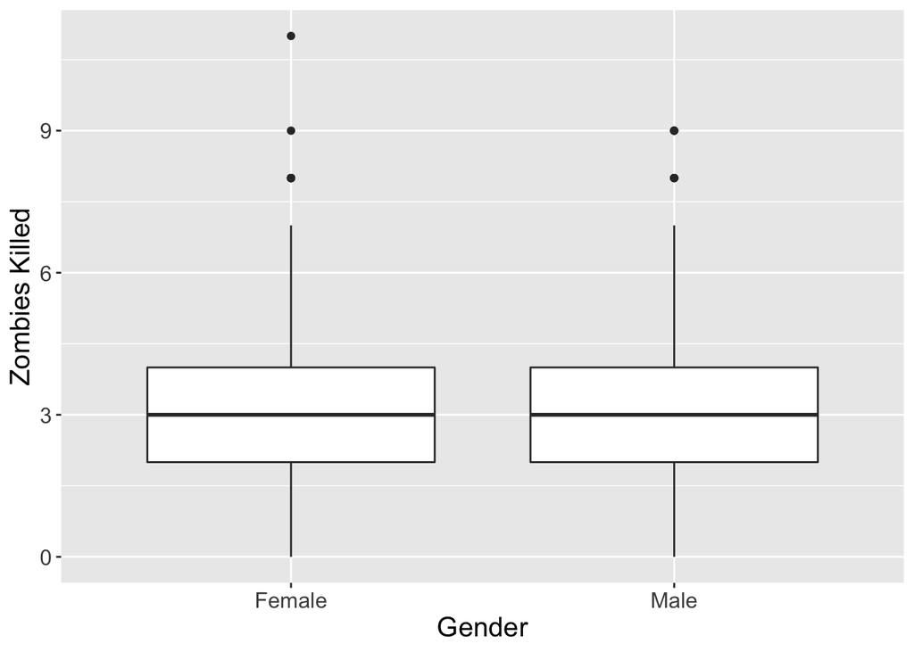

```r
zbp <- ggplot(d, aes(x=gender, y= zombies_killed)) + geom_boxplot() + xlab ('Gender') + ylab ('Zombies Killed') + theme(text=element_text(size=15))
zbp
```

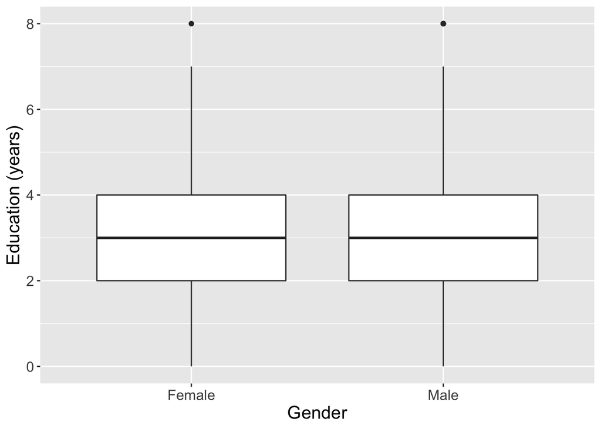

```r
ebp <- ggplot(d, aes(x=gender, y= years_of_education)) + geom_boxplot() + theme(text=element_text(size=15)) + xlab ('Gender') + ylab ('Education (years)')
ebp
```

Use {ggplot} to make scatterplots of height and weight in relation to age. Do these variables seem to be related? In what way?

A relatively strong positive linear relationship between height and age.

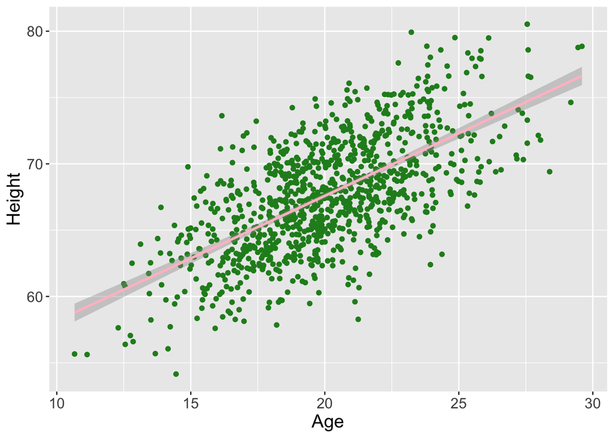

```r
hsp <- ggplot(d, aes(x=age, y=height)) #create a ggplot object
hsp <- hsp + geom_point(col='forest green') #create scatterplot #col= calls color for data points
hsp <- hsp + geom_smooth(method = 'lm', col='pink') #add a linear regression line
hsp <- hsp + theme(text=element_text(size=15)) + ylab('Height') + xlab('Age')
hsp
```

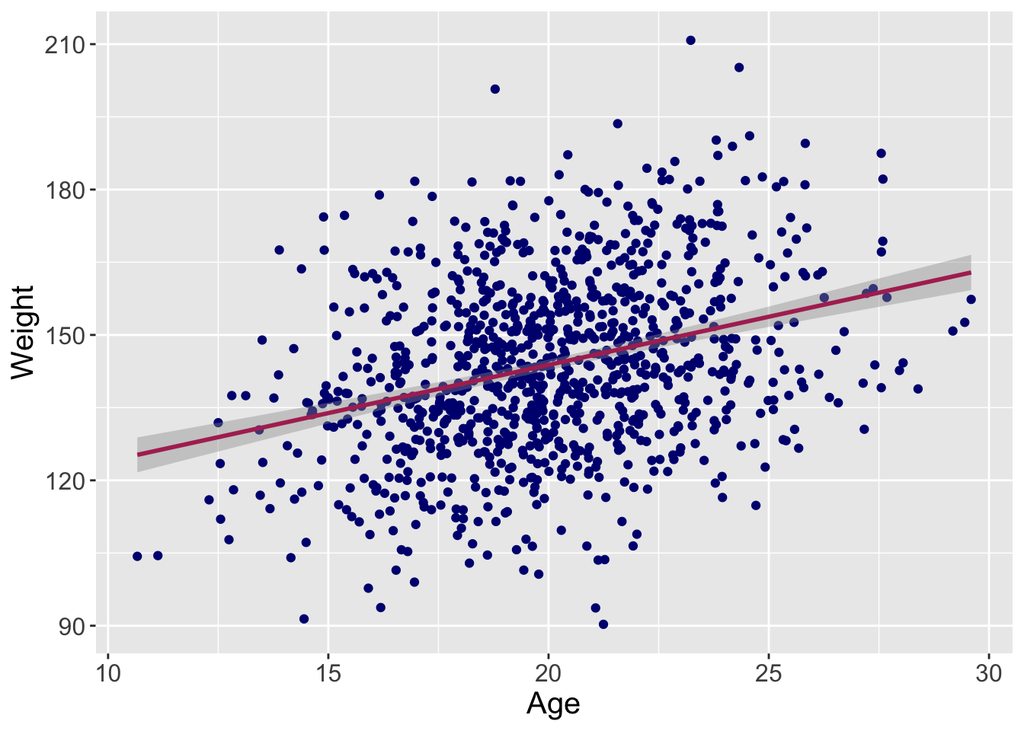

```r
wsp <- ggplot(d, aes(x=age, y=weight)) + geom_point(col='navy') + geom_smooth(method = 'lm', col= 'maroon') + theme(text=element_text(size=15)) + ylab('Weight') + xlab('Age')
wsp
```

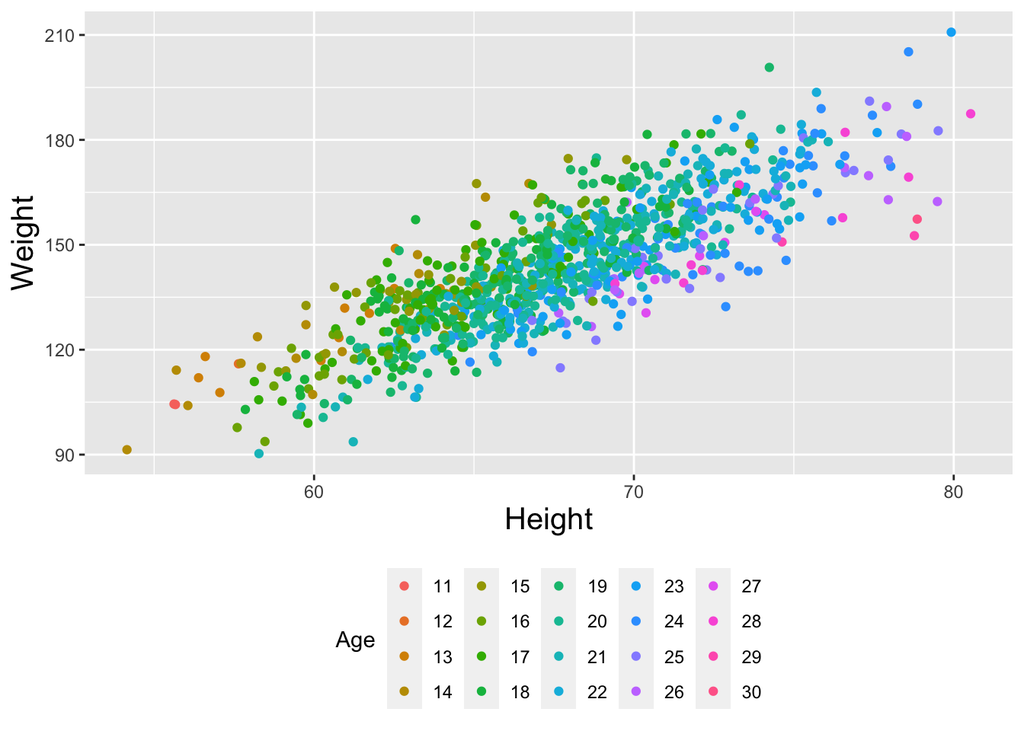

```r
age.r <- round(d$age) #round up ages to a whole number to minimize noise of coloring/factoring by age when creating the scatterplot
sp <- ggplot(d, aes(x=height, y= weight, color = factor(age.r)))  + geom_point()
#+ geom_smooth(method = 'lm') #creates a regression line for every age, too much noise
sp <- sp + theme(axis.title=element_text(size=15), legend.position = 'bottom')  + labs(x= 'Height', y='Weight', color= 'Age') #color changes the legend title manually presumably because we are factoring a variable by color.
sp
```

*Lookng for two graphs here, one for age v height and one for age v weight, so you can look for a trend*

### Checking for Normality

Using histograms and Q-Q plots, check whether the quantitative variables seem to be drawn from a normal distribution. Which seem to be and which do not (hint: not all are drawn from the normal distribution)? For those that are not normal, can you determine from which common distribution they are drawn?

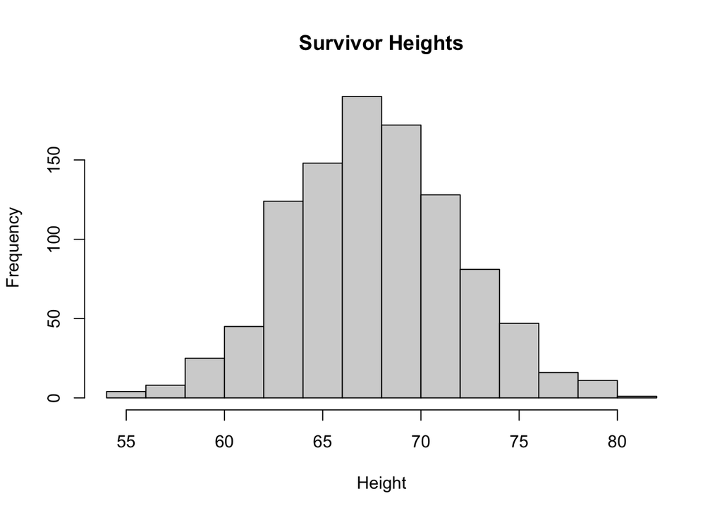

```r
hist(d$height, main = 'Survivor Heights', xlab= 'Height') #extra arguments are just defining characters as the axes labels to make the plot look better.
```

- A “Q-Q” plot can be used to look at the normality of a set of data. You can plot the quantiles for your actual data (as the y values) versus quantiles for a correspondingly standardized normal distribution (as the x values). If the two distributions being compared are similar, the points in the plot will approximately lie on the line y = x.

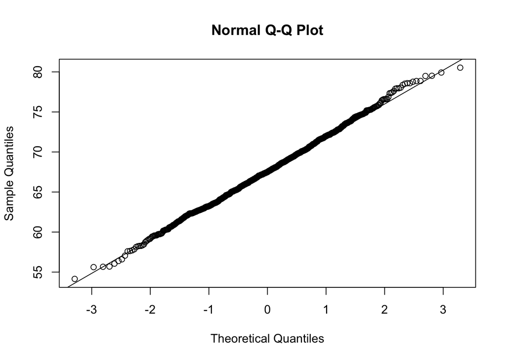

```r
qqnorm(d$height) #to generate a qq plot just call the qq norm function for your variable of interest.
qqline(d$height) # adds a best fit line along which the generated and actual data regression should lie.
```

Therefore based on the histogram of our actual data and the QQ plot we can assume height in this population is normally distributed.

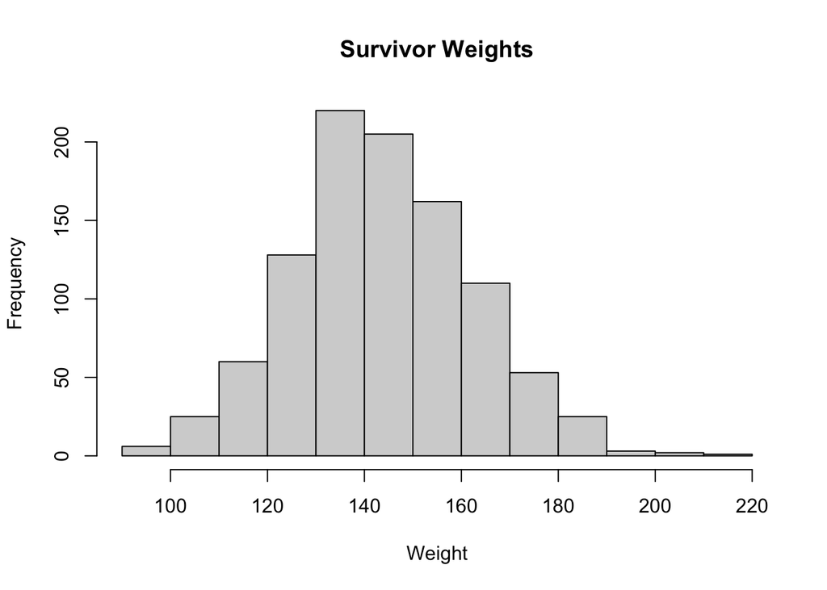

```r
hist(d$weight,  main = 'Survivor Weights', xlab= 'Weight')
```

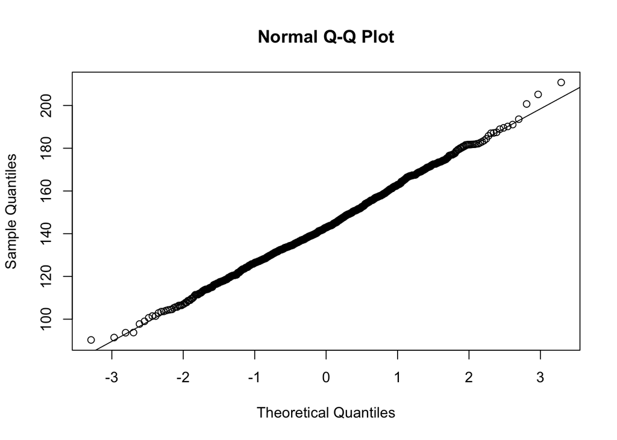

```r
qqnorm(d$weight)
qqline(d$weight)
```

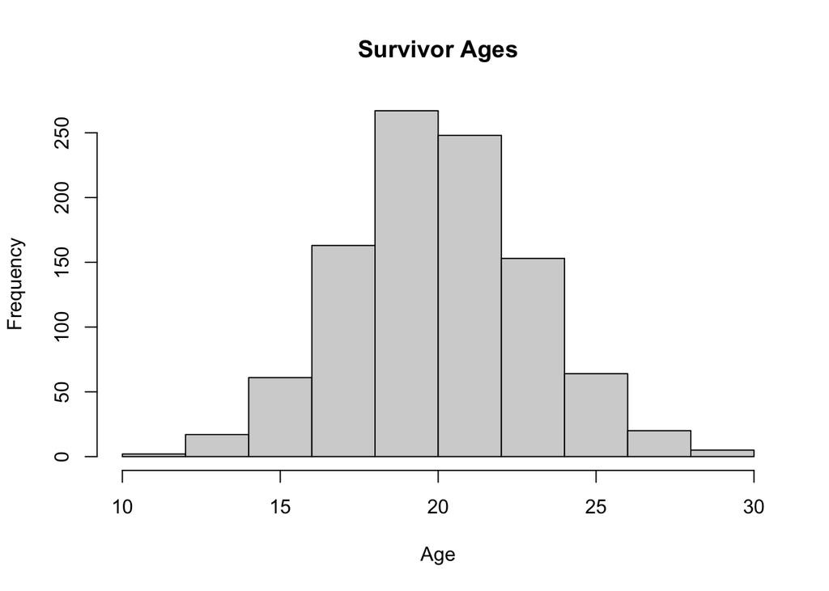

```r
hist(d$age,  main = 'Survivor Ages', xlab= 'Age')
```

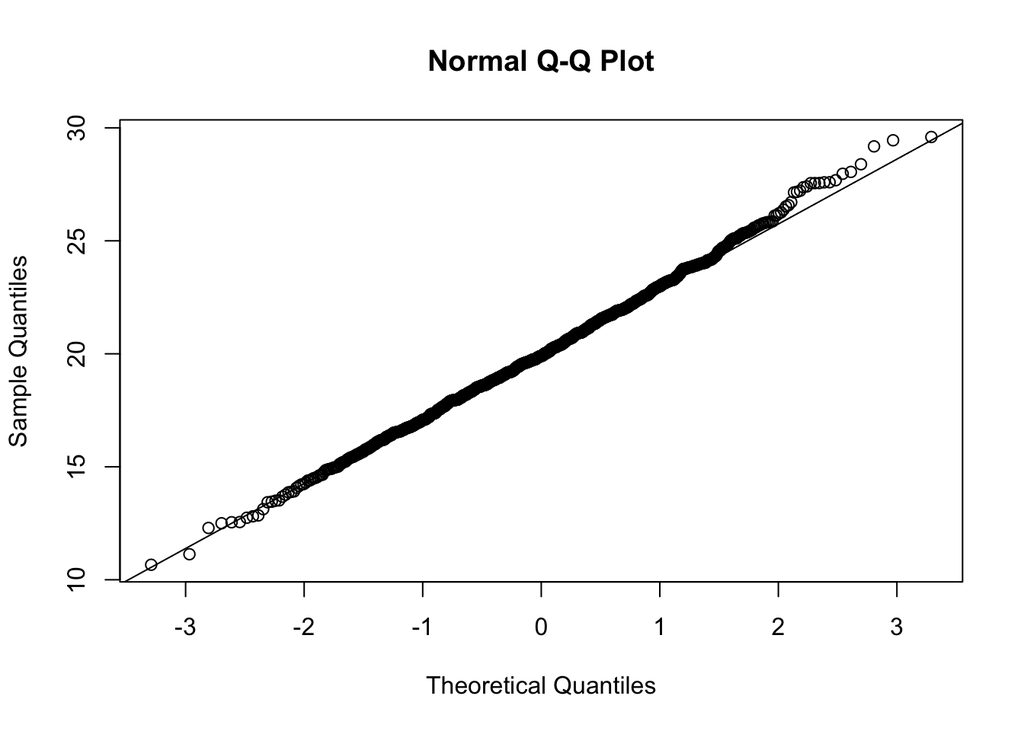

```r
qqnorm(d$age)
qqline(d$age)
```

Age is normally distributed.

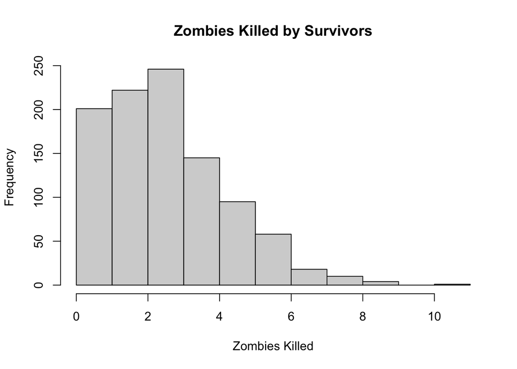

```r
hist(d$zombies_killed, main = 'Zombies Killed by Survivors', xlab= 'Zombies Killed')
```

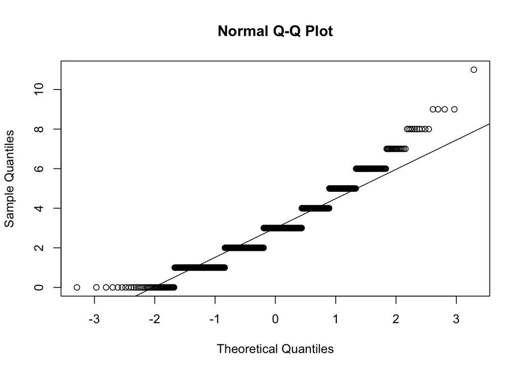

```r
qqnorm(d$zombies_killed)
qqline(d$zombies_killed)
```

Zombies killed are not normally distributed. From the histogram it looks like this data is following a Bernoulli distribution which is rationale as it is count data (starts at 0 and has discrete values based on a number of quantified successes (kills)) out of two possible outcomes (killed or not killed). Since they are discrete counts there is also a possibility that it could be following a Poisson distribution but I think Bernoulli fits the data better.

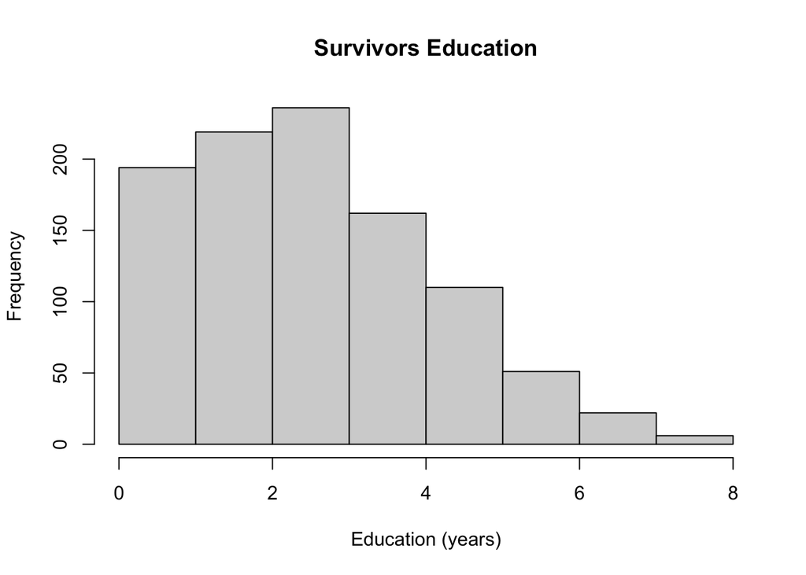

```r
hist(d$years_of_education,  main = 'Survivors Education', xlab= 'Education (years)')
```

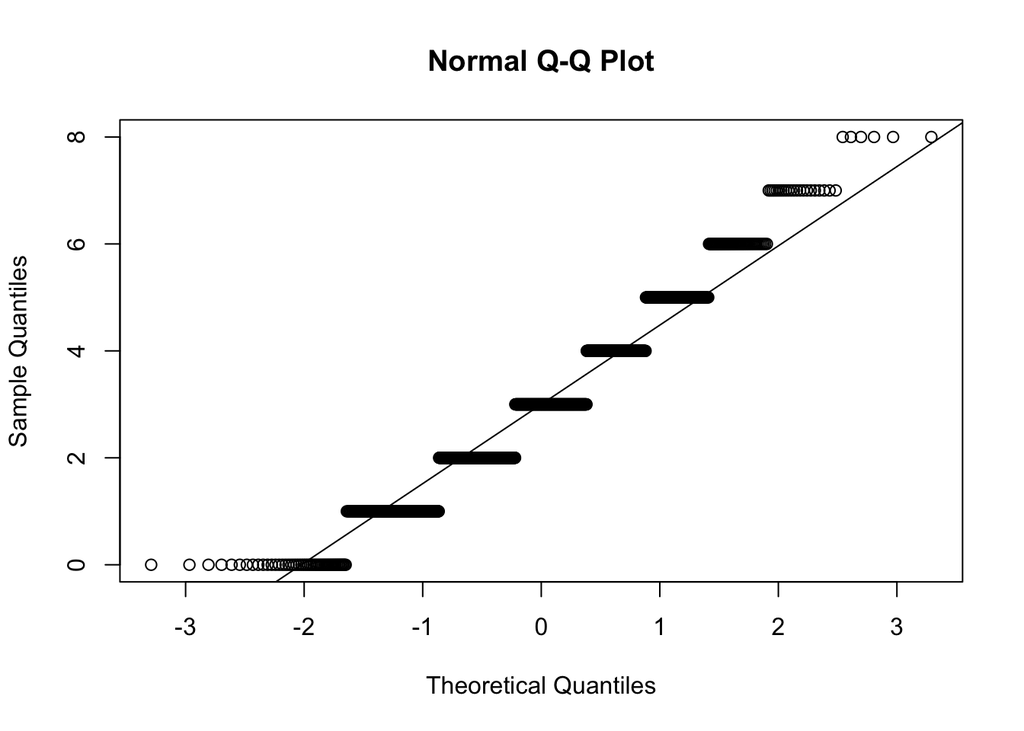

```r
qqnorm(d$years_of_education)
qqline(d$years_of_education)
```

Years of education is not normally distributed. It looks very similarly distributed when compared to the zombies killed data and for the same logic I would assume years of education is following a binomial distribution.

### Testing for Non-Normal Distributions

We can test for these assumptions by generating Poisson and Bernoulli distributed data and comparing it to the trends we see in our data to see if they fit.

We can use the binomial r function to test a Bernoulli distribution as Bernoulli is just the binomial distribution with only 2 outcomes. n is the number of realizations, size is the number of trials you want run per realization and the probability is the likelihood of success at each realization, in our case out of two independent outcomes the probability would be 1/2. I set n to 1000 as there are 1000 survivors in the original data set. I set size to 6 because a binomial distribution is defined as the mean being equal to n (number of trials) multiplied by p (probability of success at each trial). We know the mean of our data is almost 3 and the probability is 1/2 so the size should be 6.

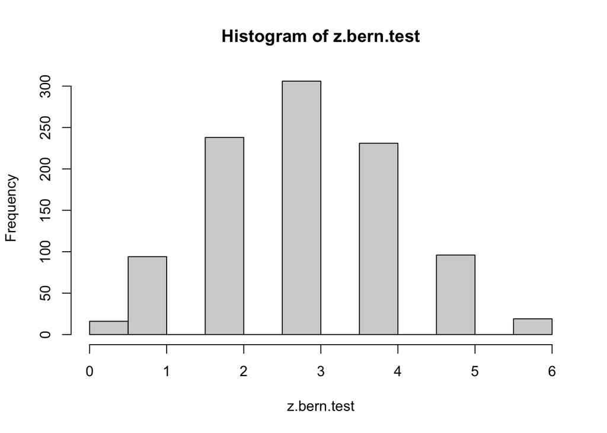

```r
z.bern.test <- rbinom(n = 1000, size = 6, prob = 1/2)
hist(z.bern.test) #Looks more normally distributed than a binomial distribution?
```

We can also just look at a PMF of a binomial distribution based on our parameters.

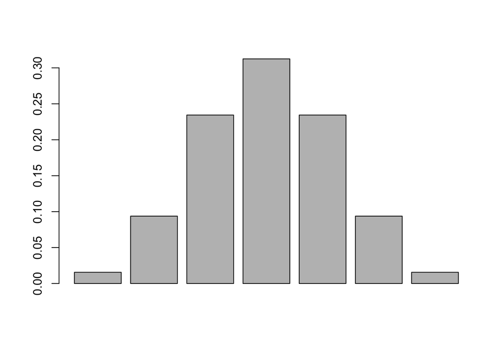

```r
z.bern.dist <- dbinom(x= 0:6,size= 6, prob= 1/2)
barplot(z.bern.dist) #Also looking very normally distributed?
```

We can do similar tests with the built in R functions for the Poisson distribution. The Poisson distribution is defined as the mean being equal to the lambda parameter. Again our mean for this variable is close to 3.

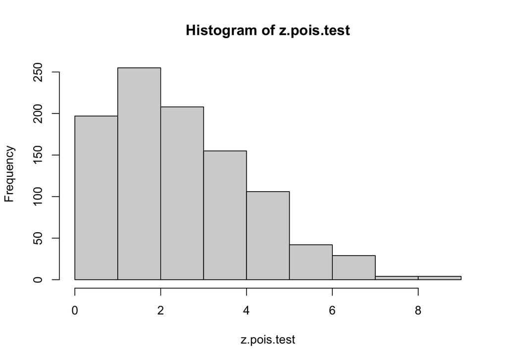

```r
z.pois.test<- rpois(n = 1000, lambda = 3)
hist(z.pois.test) #Almost identical to our population distribution!
```

```r
max(d$zombies_killed)
```

```
## [1] 11
```

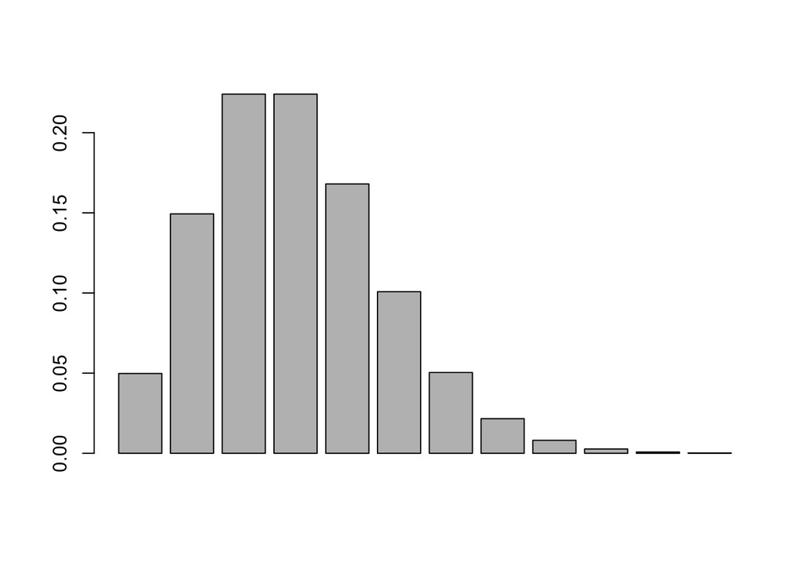

```r
z.pois.dist <- dpois(0:11, 3) # chose random variable of 11 to generate poisson distribution because in our data the maximum zombies killed is 11
barplot(z.pois.dist)
```

We can look at the education variable in a similar way. The mean of the education data is close to 3. We will assume the probability of completing or not completing a year of school is equal (meaning the probability is 1/2). Since these parameters are identical to the zombie data we can just look back at the previous chunks to see how well the education data compares to the generated data. The only graph that would produce a slightly different result is the poisson PMF because the maximum years of education attained was 8 (compared to a maximum of 11 zombies killed)

```r
max(d$years_of_education)
```

```
## [1] 8
```

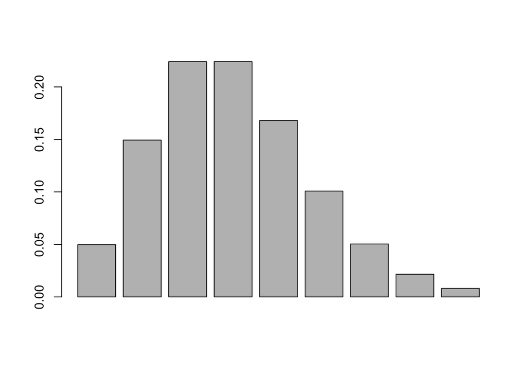

```r
z.pois.dist <- dpois(0:8, 3) # chose random variable of 8 to generate poisson distribution because in our data the maximum years of education completed is 8
barplot(z.pois.dist)
```

So overall my original assumption that the bernoulli distribution was a better fit than the poisson distribution is unlikely based on comparing generated data to the original data set.

*awesome!*

## Sample Statistics

Now use the sample() function to sample ONE subset of 30 zombie survivors (without replacement) from this population.

```r
set.seed(1)
sample.d <- d[sample(1:nrow(d),30,replace = FALSE), ] #subsetting data frame d so that it only consists of a random sample of 30 rows. replacement is set to FALSE.
rownames(sample.d) <- c() #removing row names that were assigned during subsetting. Not necessary as they are already catalogged under id variable.
sample.d
```

```
##     id  first_name last_name gender   height   weight zombies_killed
## 1  836       Susan   Hawkins Female 69.35963 133.1018              3
## 2  679    Benjamin      Ward   Male 61.95252 139.9611              2
## 3  129      Martin    Wagner   Male 70.26668 154.6746              2
## 4  930       Keith    Wagner   Male 63.24096 132.8480              3
## 5  509       Doris      Lane Female 62.33275 134.0491              3
## 6  471    Jennifer  Williams Female 62.29205 144.9394              2
## 7  299       Kelly     Burke Female 69.91124 145.7389              5
## 8  270 Christopher       Lee   Male 67.64806 130.5163              2
## 9  978      Willie  Richards   Male 64.73728 133.3641              5
## 10 187         Ann      Reid Female 71.02192 141.7984              2
## 11 307        Judy    Peters Female 63.76315 127.8650              4
## 12 597       Linda Patterson Female 63.14829 106.4643              2
## 13 277      Carlos Alexander   Male 75.21887 176.9457              3
## 14 874        Sean    Brooks   Male 68.52690 126.8207              1
```

[output cut: 47 more lines]

### Sample Mean

Calculate the mean for each variable.

```r
hmu <- mean(sample.d$height)
hmu
```

```
## [1] 66.88522
```

```r
wmu <- mean(sample.d$weight)
wmu
```

```
## [1] 142.2536
```

```r
amu <- mean(sample.d$age)
amu
```

```
## [1] 19.68657
```

```r
zmu <- mean(sample.d$zombies_killed)
zmu
```

```
## [1] 3.066667
```

```r
emu <- mean(sample.d$years_of_education)
emu
```

```
## [1] 2.966667
```

### Sample Standard Deviation

Calculate the standard deviation for each variable.

The standard deviation is simply the square root of the variance. Where the sample variance = estimator of the population variance = sum of squares / (n - 1). Using this information we can write our own functions.

```r
samplev <- function(x) {
    sum((x - mean(x))^2)/(length(x) - 1)
}
```

```r
sample.sd <- function(x) {
    sqrt(samplev(x))
}
```

OR we can use the built in R functions as we are now using sample data and either option will return the same result.

```r
sample.sd(sample.d$height)
```

```
## [1] 3.735037
```

```r
hsig <- sd(sample.d$height)
hsig
```

```
## [1] 3.735037
```

```r
sample.sd(sample.d$weight)
```

```
## [1] 16.22658
```

```r
wsig <- sd(sample.d$weight)
wsig
```

```
## [1] 16.22658
```

```r
sample.sd(sample.d$age)
```

```
## [1] 2.960476
```

```r
asig <- sd(sample.d$age)
asig
```

```
## [1] 2.960476
```

```r
sample.sd(sample.d$zombies_killed)
```

```
## [1] 1.680175
```

```r
zsig <- sd(sample.d$zombies_killed)
zsig
```

```
## [1] 1.680175
```

```r
sample.sd(sample.d$years_of_education)
```

```
## [1] 1.691425
```

```r
esig <- sd(sample.d$years_of_education)
esig
```

```
## [1] 1.691425
```

### Standard Error

Estimate the standard error for each variable.

The standard error of the mean can be defined as SE mean = square root of (sample variance / number of observations).

We can use this to write the following function.

```r
SEM <- function(x) {
    sqrt(var(x)/length(x))
}
```

```r
hse <- SEM(sample.d$height)
hse
```

```
## [1] 0.6819214
```

```r
wse <- SEM(sample.d$weight)
wse
```

```
## [1] 2.962555
```

```r
ase <- SEM(sample.d$age)
ase
```

```
## [1] 0.5405065
```

```r
zse <- SEM(sample.d$zombies_killed)
zse
```

```
## [1] 0.3067566
```

```r
ese <- SEM(sample.d$years_of_education)
ese
```

```
## [1] 0.3088106
```

### Confidence Intervals

Construct the 95% confidence interval for each mean. Note that for the variables that are not drawn from the normal distribution, you may need to base your estimate of the CIs on slightly different code than for the normal…

#### Normally Distributed variables (height, weight, age)

CI = statistic +- critical value * standard error

In this case we will use the sample mean as our statistic and we will assume a critical value of .05 (or CI level of .95). Normally distributed variables utilize the qnorm function to tell us the cumulative probability for the specified confidence level/critical value. We know from our population data that height, weight and age are normally distributed. Therefore we could use the following function:

```r
normalCI <-  function(x, CIlevel = 0.95) {
    upper = mean(x) + qnorm(1 - (1 - CIlevel)/2) * sqrt(var(x)/length(x))
    lower = mean(x) + qnorm((1 - CIlevel)/2) * sqrt(var(x)/length(x))
    ci <- c(lower, upper)
    return(ci)
}
```

Note: We divide the critical value by 2 for the calculations because we total the upper and lower tails to get the total critical value.

BUT

If we didn’t know this from our population parameter analysis and we only had this one sample of 30 individuals it would be safer and much more likely that we would use a t test instead of the normal z test for our analyses. Therefore we would adjust the function to look like this:

```r
t.test.CI <-  function(x, CIlevel = 0.95) {
    upper = mean(x) + qt(1 - (1 - CIlevel)/2, df= length(x)-1) * sqrt(var(x)/length(x))
    lower = mean(x) + qt((1 - CIlevel)/2, df= length(x)-1) * sqrt(var(x)/length(x))
    ci <- c(lower, upper)
    return(ci)
}
```

```r
normalCI(sample.d$height)
```

```
## [1] 65.54868 68.22176
```

```r
t.test.CI(sample.d$height)
```

```
## [1] 65.49053 68.27990
```

```r
normalCI(sample.d$weight)
```

```
## [1] 136.4471 148.0601
```

```r
t.test.CI(sample.d$weight)
```

```
## [1] 136.1945 148.3127
```

```r
normalCI(sample.d$age)
```

```
## [1] 18.62719 20.74594
```

```r
t.test.CI(sample.d$age)
```

```
## [1] 18.58111 20.79203
```

As you can see the CIs are very close with the t.test CIs slightly wider than the normal CIs to account for uncertainty and error inherent in a smaller sample size.

#### Non-normal variables (Zombies killed, years of education)

Simulation allows us to calculate CIs without assuming a normal distribution.

```r
zset <- NULL  # sets up a dummy variable to hold our 10000 simulations
n <- 30 #our sample size, the amount of numbers taken from out sample (with replacement)
for (i in 1:10000) {
    zset[i] <- mean(sample(sample.d$zombies_killed, n, replace = TRUE)) #replace with 1000 instead of 10000 because it can artificially reduce standard deviations so you can't apply to original population.
} #read as: sample the vector sample.d$zombies killed 30 times then take the mean. Repeat this 10,000 times and for each time place the output in the set zset.
```

The quantile() function will give us the number of observations out of the 10,000 samples that satisfy a specific quantile or CI level. We want a CI interval of 95% confidence.

```r
zCI <- quantile(zset, c(0.025, 0.975))
zCI
```

```
##     2.5%    97.5%
## 2.500000 3.666667
```

```r
eset <- NULL
n <- 30
for (i in 1:10000) {
    eset[i] <- mean(sample(sample.d$years_of_education, n, replace = TRUE))
}
```

```r
eCI <- quantile(eset, c(0.025, 0.975))
eCI
```

```
##     2.5%    97.5%
## 2.366667 3.566667
```

## Sampling Distributions

### Loop Sampling

Question 6.

Here we generate 99 more samples of 30 from the population data and place it into a list called set.100

```r
set.100 <- NULL
for (i in 1:99) {
  set.100[[i]] <-
     d[sample(1:nrow(d),30,replace = FALSE), ]
} #Since you are creating a list you need to subset it by using double brackets instead of single.
```

To complete the list we add in our original sample as the 100th element

```r
set.100[[100]] <- sample.d
```

### Calculating the Sampling Distribution

We then take the mean of a specified variable for all 100 samples to create a sampling distribution for that variable.

```r
h.sampling.distribution <- NULL
for (i in 1:100) {
  h.sampling.distribution [i] <- mean(set.100[[i]][ ,'height'])
} #read as: take the mean of the column titled height for each element of set.100 from 1 to 100 and pipe that into elements 1:100 of a new set called h.sampling.distribution.
```

```r
w.sampling.distribution <- NULL
for (i in 1:100) {
  w.sampling.distribution [i] <- mean(set.100[[i]][ ,'weight'])
}
```

```r
a.sampling.distribution <- NULL
for (i in 1:100) {
  a.sampling.distribution [i] <- mean(set.100[[i]][ ,'age'])
}
```

```r
z.sampling.distribution <- NULL
for (i in 1:100) {
  z.sampling.distribution [i] <- mean(set.100[[i]][ ,'zombies_killed'])
}
```

```r
e.sampling.distribution <- NULL
for (i in 1:100) {
  e.sampling.distribution [i] <- mean(set.100[[i]][ ,'years_of_education'])
}
```

### Sampling Distribution statistics

What are the means and standard deviations of this distribution of means for each variable? How do the standard deviations of means compare to the standard errors?

```r
mean(h.sampling.distribution)
```

```
## [1] 67.70713
```

```r
sd(h.sampling.distribution)
```

```
## [1] 0.7409467
```

```r
mean(w.sampling.distribution)
```

```
## [1] 144.2538
```

```r
sd(w.sampling.distribution)
```

```
## [1] 3.06329
```

```r
mean(a.sampling.distribution)
```

```
## [1] 20.16904
```

```r
sd(a.sampling.distribution)
```

```
## [1] 0.5178417
```

```r
mean(z.sampling.distribution)
```

```
## [1] 3.051667
```

```r
sd(z.sampling.distribution)
```

```
## [1] 0.3280516
```

```r
mean(e.sampling.distribution)
```

```
## [1] 2.977667
```

```r
sd(e.sampling.distribution)
```

```
## [1] 0.3214046
```

### Sampling Distribution Visualization

What do these sampling distributions look like (a graph might help here)?

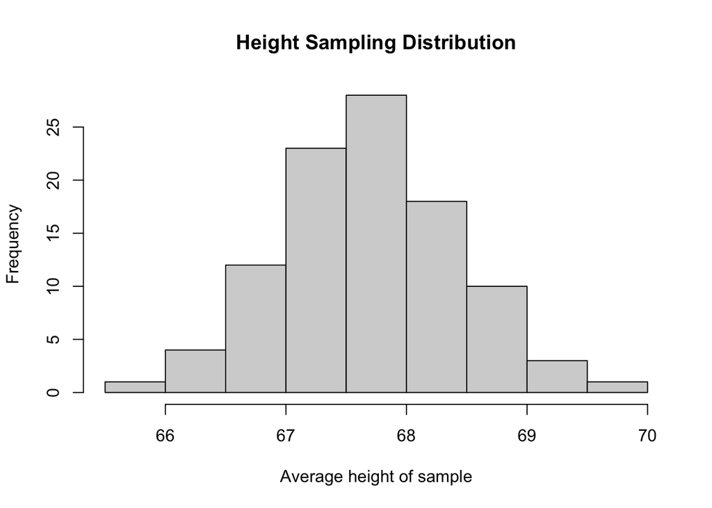

```r
hist(h.sampling.distribution,  main = 'Height Sampling Distribution', xlab= 'Average height of sample')
```

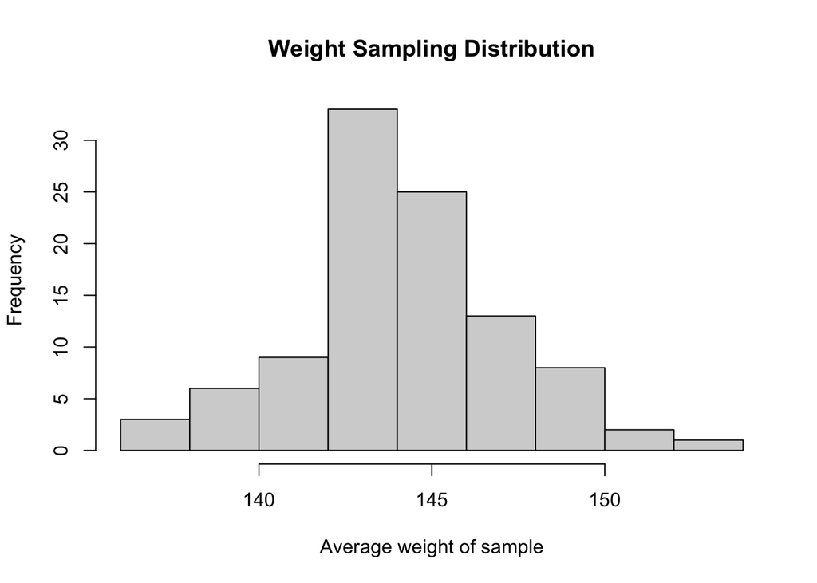

```r
hist(w.sampling.distribution,  main = 'Weight Sampling Distribution', xlab= 'Average weight of sample')
```

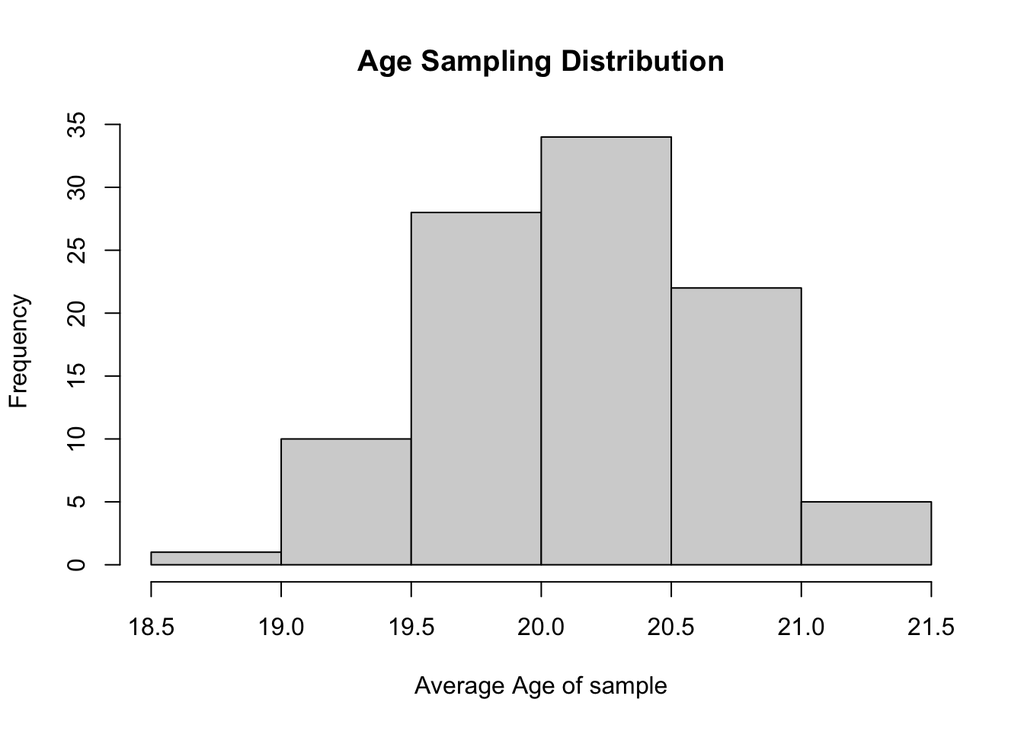

```r
hist(a.sampling.distribution,  main = 'Age Sampling Distribution', xlab= 'Average Age of sample')
```

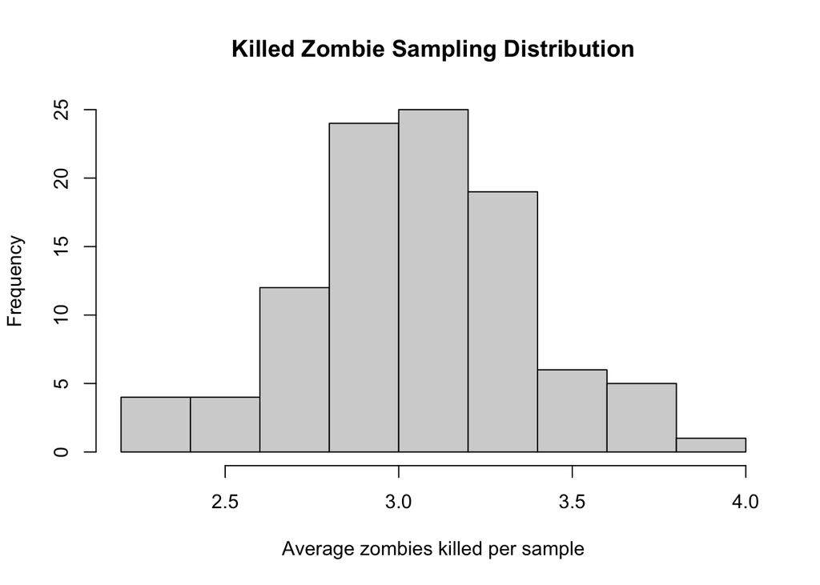

```r
hist(z.sampling.distribution,  main = 'Killed Zombie Sampling Distribution', xlab= 'Average zombies killed per sample')
```

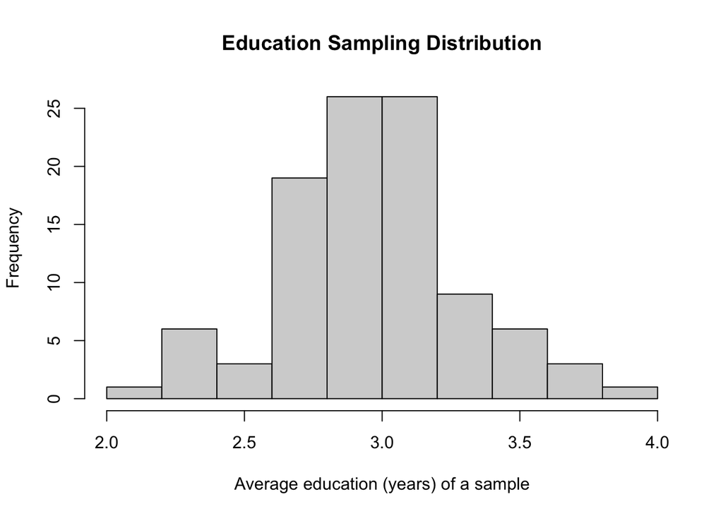

```r
hist(e.sampling.distribution, main = 'Education Sampling Distribution', xlab= 'Average education (years) of a sample')
```

Are they normally distributed? What about for those variables that you concluded were not originally drawn from a normal distribution?

# Challenges:

1. Understanding what distribution the population random variables came from? Attempting to test for non normal distributions by comparing generated to existing data went well for Poisson but I think I went wrong somewhere generating the Binomial/Bernoulli distributions because they look normally distributed?
2. The sample function requires the input of a vector. It was taking the length of the data frame as 10 (variables) instead of 1000 (observations). To use the sample function to sample a number of rows from the data frame I had to first subset the data frame.
3. The looping for question number 6 was difficult but I think most of my problems were with the fact that the loop was generating a list object which meant I needed to subset it using double brackets. Once I realized that the rest was kind of plug and play with the original code given in the modules.
4. I would love a more in depth tutorial of ggplot because I always get lost. There are a lot of additional functions that can get overwhelming but I got where I wanted to go in the end by looking at the cheat sheet. *https://ggplot2.tidyverse.org/reference/*

*great work!*